# Risk Factor Analysis

## Outcome Variable

**Outcome Variable:** wasted

## Predictor Variables

**Intervention Variable:** birthlen

**Adjustment Set:**

unadjusted

## Stratifying Variables

The analysis was stratified on these variable(s):

- agecat
- studyid
- country

## Data Summary

| agecat | studyid | country | birthlen | wasted | n_cell | n | outcome_variable |
| --- | --- | --- | --- | --- | --- | --- | --- |
| Birth | ki0047075b-MAL-ED | BANGLADESH | >=50 cm | 0 | 30 | 215 | wasted |
| Birth | ki0047075b-MAL-ED | BANGLADESH | >=50 cm | 1 | 9 | 215 | wasted |
| Birth | ki0047075b-MAL-ED | BANGLADESH | <48 cm | 0 | 81 | 215 | wasted |
| Birth | ki0047075b-MAL-ED | BANGLADESH | <48 cm | 1 | 16 | 215 | wasted |
| Birth | ki0047075b-MAL-ED | BANGLADESH | [48-50) cm | 0 | 68 | 215 | wasted |
| Birth | ki0047075b-MAL-ED | BANGLADESH | [48-50) cm | 1 | 11 | 215 | wasted |
| Birth | ki0047075b-MAL-ED | BRAZIL | >=50 cm | 0 | 30 | 62 | wasted |
| Birth | ki0047075b-MAL-ED | BRAZIL | >=50 cm | 1 | 0 | 62 | wasted |
| Birth | ki0047075b-MAL-ED | BRAZIL | <48 cm | 0 | 13 | 62 | wasted |
| Birth | ki0047075b-MAL-ED | BRAZIL | <48 cm | 1 | 1 | 62 | wasted |
| Birth | ki0047075b-MAL-ED | BRAZIL | [48-50) cm | 0 | 17 | 62 | wasted |
| Birth | ki0047075b-MAL-ED | BRAZIL | [48-50) cm | 1 | 1 | 62 | wasted |
| Birth | ki0047075b-MAL-ED | INDIA | >=50 cm | 0 | 8 | 45 | wasted |
| Birth | ki0047075b-MAL-ED | INDIA | >=50 cm | 1 | 1 | 45 | wasted |
| Birth | ki0047075b-MAL-ED | INDIA | <48 cm | 0 | 16 | 45 | wasted |
| Birth | ki0047075b-MAL-ED | INDIA | <48 cm | 1 | 2 | 45 | wasted |
| Birth | ki0047075b-MAL-ED | INDIA | [48-50) cm | 0 | 16 | 45 | wasted |
| Birth | ki0047075b-MAL-ED | INDIA | [48-50) cm | 1 | 2 | 45 | wasted |
| Birth | ki0047075b-MAL-ED | NEPAL | >=50 cm | 0 | 8 | 26 | wasted |
| Birth | ki0047075b-MAL-ED | NEPAL | >=50 cm | 1 | 0 | 26 | wasted |
| Birth | ki0047075b-MAL-ED | NEPAL | <48 cm | 0 | 9 | 26 | wasted |
| Birth | ki0047075b-MAL-ED | NEPAL | <48 cm | 1 | 2 | 26 | wasted |
| Birth | ki0047075b-MAL-ED | NEPAL | [48-50) cm | 0 | 7 | 26 | wasted |
| Birth | ki0047075b-MAL-ED | NEPAL | [48-50) cm | 1 | 0 | 26 | wasted |
| Birth | ki0047075b-MAL-ED | PERU | >=50 cm | 0 | 51 | 228 | wasted |
| Birth | ki0047075b-MAL-ED | PERU | >=50 cm | 1 | 1 | 228 | wasted |
| Birth | ki0047075b-MAL-ED | PERU | <48 cm | 0 | 81 | 228 | wasted |
| Birth | ki0047075b-MAL-ED | PERU | <48 cm | 1 | 2 | 228 | wasted |
| Birth | ki0047075b-MAL-ED | PERU | [48-50) cm | 0 | 91 | 228 | wasted |
| Birth | ki0047075b-MAL-ED | PERU | [48-50) cm | 1 | 2 | 228 | wasted |

[output cut: 426 more lines]

The following strata were considered:

- agecat: 24 months, studyid: ki0047075b-MAL-ED, country: BANGLADESH
- agecat: 24 months, studyid: ki0047075b-MAL-ED, country: BRAZIL
- agecat: 24 months, studyid: ki0047075b-MAL-ED, country: INDIA
- agecat: 24 months, studyid: ki0047075b-MAL-ED, country: NEPAL
- agecat: 24 months, studyid: ki0047075b-MAL-ED, country: PERU
- agecat: 24 months, studyid: ki0047075b-MAL-ED, country: SOUTH AFRICA
- agecat: 24 months, studyid: ki0047075b-MAL-ED, country: TANZANIA, UNITED REPUBLIC OF
- agecat: 24 months, studyid: ki1000108-CMC-V-BCS-2002, country: INDIA
- agecat: 24 months, studyid: ki1000108-IRC, country: INDIA
- agecat: 24 months, studyid: ki1000109-EE, country: PAKISTAN
- agecat: 24 months, studyid: ki1017093-NIH-Birth, country: BANGLADESH
- agecat: 24 months, studyid: ki1017093b-PROVIDE, country: BANGLADESH
- agecat: 24 months, studyid: ki1017093c-NIH-Crypto, country: BANGLADESH
- agecat: 24 months, studyid: ki1101329-Keneba, country: GAMBIA
- agecat: 24 months, studyid: ki1113344-GMS-Nepal, country: NEPAL
- agecat: 24 months, studyid: ki1114097-CMIN, country: BANGLADESH
- agecat: 24 months, studyid: ki1114097-CONTENT, country: PERU
- agecat: 24 months, studyid: ki1119695-PROBIT, country: BELARUS
- agecat: 24 months, studyid: ki1126311-ZVITAMBO, country: ZIMBABWE
- agecat: 24 months, studyid: ki1135781-COHORTS, country: GUATEMALA
- agecat: 24 months, studyid: ki1135781-COHORTS, country: INDIA
- agecat: 24 months, studyid: ki1135781-COHORTS, country: PHILIPPINES
- agecat: 24 months, studyid: kiGH5241-JiVitA-3, country: BANGLADESH
- agecat: 24 months, studyid: kiGH5241-JiVitA-4, country: BANGLADESH
- agecat: 6 months, studyid: ki0047075b-MAL-ED, country: BANGLADESH
- agecat: 6 months, studyid: ki0047075b-MAL-ED, country: BRAZIL
- agecat: 6 months, studyid: ki0047075b-MAL-ED, country: INDIA
- agecat: 6 months, studyid: ki0047075b-MAL-ED, country: NEPAL
- agecat: 6 months, studyid: ki0047075b-MAL-ED, country: PERU
- agecat: 6 months, studyid: ki0047075b-MAL-ED, country: SOUTH AFRICA
- agecat: 6 months, studyid: ki0047075b-MAL-ED, country: TANZANIA, UNITED REPUBLIC OF
- agecat: 6 months, studyid: ki1000108-CMC-V-BCS-2002, country: INDIA
- agecat: 6 months, studyid: ki1000108-IRC, country: INDIA
- agecat: 6 months, studyid: ki1000109-EE, country: PAKISTAN
- agecat: 6 months, studyid: ki1000109-ResPak, country: PAKISTAN
- agecat: 6 months, studyid: ki1000304b-SAS-CompFeed, country: INDIA
- agecat: 6 months, studyid: ki1017093-NIH-Birth, country: BANGLADESH
- agecat: 6 months, studyid: ki1017093b-PROVIDE, country: BANGLADESH
- agecat: 6 months, studyid: ki1017093c-NIH-Crypto, country: BANGLADESH
- agecat: 6 months, studyid: ki1101329-Keneba, country: GAMBIA
- agecat: 6 months, studyid: ki1113344-GMS-Nepal, country: NEPAL
- agecat: 6 months, studyid: ki1114097-CMIN, country: BANGLADESH
- agecat: 6 months, studyid: ki1114097-CONTENT, country: PERU
- agecat: 6 months, studyid: ki1119695-PROBIT, country: BELARUS
- agecat: 6 months, studyid: ki1126311-ZVITAMBO, country: ZIMBABWE
- agecat: 6 months, studyid: ki1135781-COHORTS, country: GUATEMALA
- agecat: 6 months, studyid: ki1135781-COHORTS, country: INDIA
- agecat: 6 months, studyid: ki1135781-COHORTS, country: PHILIPPINES
- agecat: 6 months, studyid: kiGH5241-JiVitA-3, country: BANGLADESH
- agecat: 6 months, studyid: kiGH5241-JiVitA-4, country: BANGLADESH
- agecat: Birth, studyid: ki0047075b-MAL-ED, country: BANGLADESH
- agecat: Birth, studyid: ki0047075b-MAL-ED, country: BRAZIL
- agecat: Birth, studyid: ki0047075b-MAL-ED, country: INDIA
- agecat: Birth, studyid: ki0047075b-MAL-ED, country: NEPAL
- agecat: Birth, studyid: ki0047075b-MAL-ED, country: PERU
- agecat: Birth, studyid: ki0047075b-MAL-ED, country: SOUTH AFRICA
- agecat: Birth, studyid: ki0047075b-MAL-ED, country: TANZANIA, UNITED REPUBLIC OF
- agecat: Birth, studyid: ki1000108-CMC-V-BCS-2002, country: INDIA
- agecat: Birth, studyid: ki1000108-IRC, country: INDIA
- agecat: Birth, studyid: ki1000109-EE, country: PAKISTAN
- agecat: Birth, studyid: ki1000109-ResPak, country: PAKISTAN
- agecat: Birth, studyid: ki1000304b-SAS-CompFeed, country: INDIA
- agecat: Birth, studyid: ki1017093-NIH-Birth, country: BANGLADESH
- agecat: Birth, studyid: ki1017093b-PROVIDE, country: BANGLADESH
- agecat: Birth, studyid: ki1017093c-NIH-Crypto, country: BANGLADESH
- agecat: Birth, studyid: ki1101329-Keneba, country: GAMBIA
- agecat: Birth, studyid: ki1113344-GMS-Nepal, country: NEPAL
- agecat: Birth, studyid: ki1114097-CMIN, country: BANGLADESH
- agecat: Birth, studyid: ki1114097-CONTENT, country: PERU
- agecat: Birth, studyid: ki1119695-PROBIT, country: BELARUS
- agecat: Birth, studyid: ki1126311-ZVITAMBO, country: ZIMBABWE
- agecat: Birth, studyid: ki1135781-COHORTS, country: GUATEMALA
- agecat: Birth, studyid: ki1135781-COHORTS, country: INDIA
- agecat: Birth, studyid: ki1135781-COHORTS, country: PHILIPPINES
- agecat: Birth, studyid: kiGH5241-JiVitA-3, country: BANGLADESH
- agecat: Birth, studyid: kiGH5241-JiVitA-4, country: BANGLADESH

### Dropped Strata

Some strata were dropped due to rare outcomes:

- agecat: Birth, studyid: ki0047075b-MAL-ED, country: BRAZIL
- agecat: Birth, studyid: ki0047075b-MAL-ED, country: INDIA
- agecat: Birth, studyid: ki0047075b-MAL-ED, country: NEPAL
- agecat: Birth, studyid: ki0047075b-MAL-ED, country: PERU
- agecat: Birth, studyid: ki0047075b-MAL-ED, country: SOUTH AFRICA
- agecat: Birth, studyid: ki0047075b-MAL-ED, country: TANZANIA, UNITED REPUBLIC OF
- agecat: Birth, studyid: ki1000108-CMC-V-BCS-2002, country: INDIA
- agecat: Birth, studyid: ki1000109-EE, country: PAKISTAN
- agecat: Birth, studyid: ki1000109-ResPak, country: PAKISTAN
- agecat: Birth, studyid: ki1114097-CMIN, country: BANGLADESH
- agecat: Birth, studyid: ki1114097-CONTENT, country: PERU
- agecat: Birth, studyid: ki1119695-PROBIT, country: BELARUS
- agecat: 6 months, studyid: ki0047075b-MAL-ED, country: BANGLADESH
- agecat: 6 months, studyid: ki0047075b-MAL-ED, country: BRAZIL
- agecat: 6 months, studyid: ki0047075b-MAL-ED, country: INDIA
- agecat: 6 months, studyid: ki0047075b-MAL-ED, country: NEPAL
- agecat: 6 months, studyid: ki0047075b-MAL-ED, country: PERU
- agecat: 6 months, studyid: ki0047075b-MAL-ED, country: SOUTH AFRICA
- agecat: 6 months, studyid: ki0047075b-MAL-ED, country: TANZANIA, UNITED REPUBLIC OF
- agecat: 6 months, studyid: ki1000108-CMC-V-BCS-2002, country: INDIA
- agecat: 6 months, studyid: ki1000109-EE, country: PAKISTAN
- agecat: 6 months, studyid: ki1000109-ResPak, country: PAKISTAN
- agecat: 6 months, studyid: ki1017093b-PROVIDE, country: BANGLADESH
- agecat: 6 months, studyid: ki1017093c-NIH-Crypto, country: BANGLADESH
- agecat: 6 months, studyid: ki1114097-CMIN, country: BANGLADESH
- agecat: 6 months, studyid: ki1114097-CONTENT, country: PERU
- agecat: 6 months, studyid: ki1119695-PROBIT, country: BELARUS
- agecat: 6 months, studyid: ki1135781-COHORTS, country: GUATEMALA
- agecat: 24 months, studyid: ki0047075b-MAL-ED, country: BANGLADESH
- agecat: 24 months, studyid: ki0047075b-MAL-ED, country: BRAZIL
- agecat: 24 months, studyid: ki0047075b-MAL-ED, country: INDIA
- agecat: 24 months, studyid: ki0047075b-MAL-ED, country: NEPAL
- agecat: 24 months, studyid: ki0047075b-MAL-ED, country: PERU
- agecat: 24 months, studyid: ki0047075b-MAL-ED, country: SOUTH AFRICA
- agecat: 24 months, studyid: ki0047075b-MAL-ED, country: TANZANIA, UNITED REPUBLIC OF
- agecat: 24 months, studyid: ki1000108-CMC-V-BCS-2002, country: INDIA
- agecat: 24 months, studyid: ki1000109-EE, country: PAKISTAN
- agecat: 24 months, studyid: ki1114097-CMIN, country: BANGLADESH
- agecat: 24 months, studyid: ki1114097-CONTENT, country: PERU
- agecat: 24 months, studyid: ki1119695-PROBIT, country: BELARUS
- agecat: 24 months, studyid: ki1135781-COHORTS, country: GUATEMALA

## Methods Detail

We’re interested in the causal parameters $E[Y_a]$ for all values of $a \in \mathcal{A}$. These parameters represent the mean outcome if, possibly contrary to fact, we intervened to set all units to have $A=a$. Under the randomization and positivity assumptions, these are identified by the statistical parameters $\psi_a=E_W[E_{Y|A,W}(Y|A=a,W)]$. In addition, we’re interested in the mean of $Y$, $E[Y]$ under no intervention (the observed mean). We will estimate these parameters by using SuperLearner to fit the relevant likelihood factors – $E_{Y|A,W}(Y|A=a,W)$ and $p(A=a|W)$, and then updating our likelihood fit using a joint TMLE.

For unadjusted analyses ($W=\{\}$), initial likelihoods were estimated using Lrnr_glm to estimate the simple $E(Y|A)$ and Lrnr_mean to estimate $p(A)$. For adjusted analyses, a small library containing Lrnr_glmnet, Lrnr_xgboost, and Lrnr_mean was used.

Having estimated these parameters, we will then use the delta method to estimate relative risks and attributable risks relative to a prespecified baseline level of $A$.

# Results Detail

## Results Plots

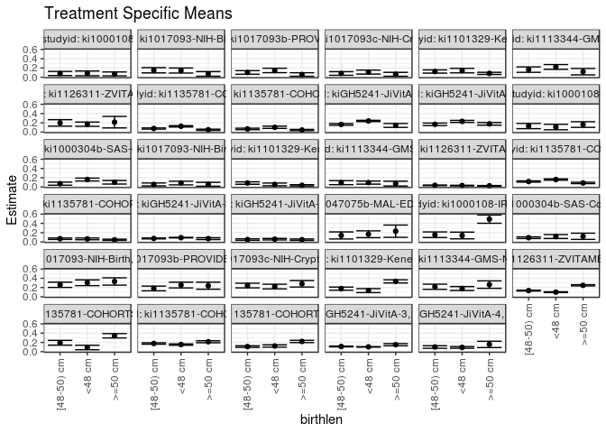

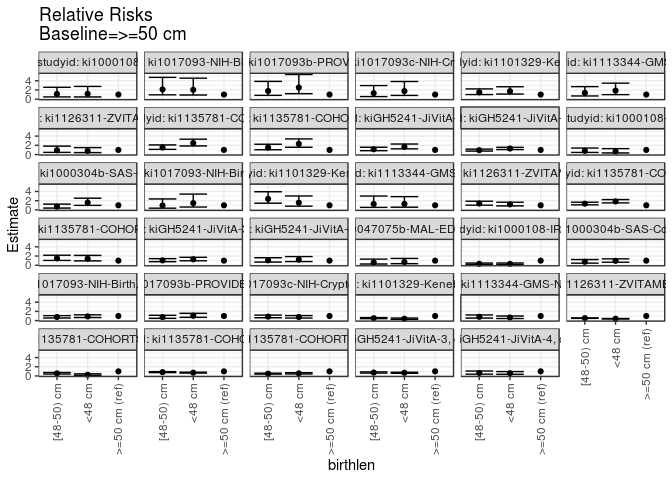

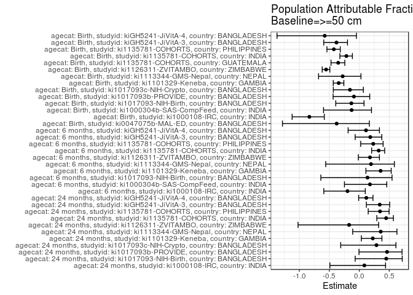

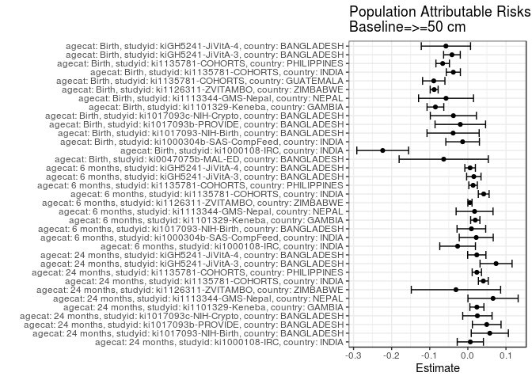

## Results Table

### Parameter: TSM

| agecat | studyid | country | intervention_level | baseline_level | estimate | ci_lower | ci_upper |
| --- | --- | --- | --- | --- | --- | --- | --- |
| Birth | ki0047075b-MAL-ED | BANGLADESH | >=50 cm | NA | 0.2307692 | 0.0982297 | 0.3633088 |
| Birth | ki0047075b-MAL-ED | BANGLADESH | <48 cm | NA | 0.1649485 | 0.0909189 | 0.2389780 |
| Birth | ki0047075b-MAL-ED | BANGLADESH | [48-50) cm | NA | 0.1392405 | 0.0627213 | 0.2157597 |
| Birth | ki1000108-IRC | INDIA | >=50 cm | NA | 0.4916667 | 0.4020887 | 0.5812446 |
| Birth | ki1000108-IRC | INDIA | <48 cm | NA | 0.1379310 | 0.0653665 | 0.2104956 |
| Birth | ki1000108-IRC | INDIA | [48-50) cm | NA | 0.1544118 | 0.0935937 | 0.2152298 |
| Birth | ki1000304b-SAS-CompFeed | INDIA | >=50 cm | NA | 0.1206897 | 0.0538324 | 0.1875469 |
| Birth | ki1000304b-SAS-CompFeed | INDIA | <48 cm | NA | 0.1152542 | 0.0728627 | 0.1576458 |
| Birth | ki1000304b-SAS-CompFeed | INDIA | [48-50) cm | NA | 0.0906801 | 0.0726326 | 0.1087276 |
| Birth | ki1017093-NIH-Birth | BANGLADESH | >=50 cm | NA | 0.3308824 | 0.2517335 | 0.4100312 |
| Birth | ki1017093-NIH-Birth | BANGLADESH | <48 cm | NA | 0.3033175 | 0.2412376 | 0.3653974 |
| Birth | ki1017093-NIH-Birth | BANGLADESH | [48-50) cm | NA | 0.2587719 | 0.2018744 | 0.3156694 |
| Birth | ki1017093b-PROVIDE | BANGLADESH | >=50 cm | NA | 0.2396694 | 0.1635367 | 0.3158022 |
| Birth | ki1017093b-PROVIDE | BANGLADESH | <48 cm | NA | 0.2539683 | 0.1918536 | 0.3160829 |
| Birth | ki1017093b-PROVIDE | BANGLADESH | [48-50) cm | NA | 0.1801802 | 0.1295752 | 0.2307851 |
| Birth | ki1017093c-NIH-Crypto | BANGLADESH | >=50 cm | NA | 0.2812500 | 0.2115343 | 0.3509657 |
| Birth | ki1017093c-NIH-Crypto | BANGLADESH | <48 cm | NA | 0.2209738 | 0.1711718 | 0.2707757 |
| Birth | ki1017093c-NIH-Crypto | BANGLADESH | [48-50) cm | NA | 0.2428571 | 0.1925950 | 0.2931193 |
| Birth | ki1101329-Keneba | GAMBIA | >=50 cm | NA | 0.3328804 | 0.2988237 | 0.3669372 |
| Birth | ki1101329-Keneba | GAMBIA | <48 cm | NA | 0.1333333 | 0.0903118 | 0.1763549 |
| Birth | ki1101329-Keneba | GAMBIA | [48-50) cm | NA | 0.1758691 | 0.1421144 | 0.2096239 |
| Birth | ki1113344-GMS-Nepal | NEPAL | >=50 cm | NA | 0.2631579 | 0.1822613 | 0.3440545 |
| Birth | ki1113344-GMS-Nepal | NEPAL | <48 cm | NA | 0.1786834 | 0.1366118 | 0.2207550 |
| Birth | ki1113344-GMS-Nepal | NEPAL | [48-50) cm | NA | 0.2163462 | 0.1603456 | 0.2723467 |
| Birth | ki1126311-ZVITAMBO | ZIMBABWE | >=50 cm | NA | 0.2479360 | 0.2345486 | 0.2613233 |
| Birth | ki1126311-ZVITAMBO | ZIMBABWE | <48 cm | NA | 0.1002472 | 0.0904916 | 0.1100027 |
| Birth | ki1126311-ZVITAMBO | ZIMBABWE | [48-50) cm | NA | 0.1335480 | 0.1243715 | 0.1427246 |
| Birth | ki1135781-COHORTS | GUATEMALA | >=50 cm | NA | 0.3434343 | 0.2966340 | 0.3902347 |
| Birth | ki1135781-COHORTS | GUATEMALA | <48 cm | NA | 0.0909091 | 0.0418346 | 0.1399836 |
| Birth | ki1135781-COHORTS | GUATEMALA | [48-50) cm | NA | 0.1929825 | 0.1417236 | 0.2442413 |

[output cut: 75 more lines]

### Parameter: E(Y)

| agecat | studyid | country | intervention_level | baseline_level | estimate | ci_lower | ci_upper |
| --- | --- | --- | --- | --- | --- | --- | --- |
| Birth | ki0047075b-MAL-ED | BANGLADESH | NA | NA | 0.1674419 | 0.1174176 | 0.2174661 |
| Birth | ki1000108-IRC | INDIA | NA | NA | 0.2682216 | 0.2212677 | 0.3151755 |
| Birth | ki1000304b-SAS-CompFeed | INDIA | NA | NA | 0.1069810 | 0.0760961 | 0.1378659 |
| Birth | ki1017093-NIH-Birth | BANGLADESH | NA | NA | 0.2921739 | 0.2549711 | 0.3293768 |
| Birth | ki1017093b-PROVIDE | BANGLADESH | NA | NA | 0.2199248 | 0.1846953 | 0.2551543 |
| Birth | ki1017093c-NIH-Crypto | BANGLADESH | NA | NA | 0.2432815 | 0.2116319 | 0.2749310 |
| Birth | ki1101329-Keneba | GAMBIA | NA | NA | 0.2477816 | 0.2256667 | 0.2698964 |
| Birth | ki1113344-GMS-Nepal | NEPAL | NA | NA | 0.2059282 | 0.1745993 | 0.2372572 |
| Birth | ki1126311-ZVITAMBO | ZIMBABWE | NA | NA | 0.1595572 | 0.1532418 | 0.1658725 |
| Birth | ki1135781-COHORTS | GUATEMALA | NA | NA | 0.2539683 | 0.2229196 | 0.2850169 |
| Birth | ki1135781-COHORTS | INDIA | NA | NA | 0.1769740 | 0.1674681 | 0.1864799 |
| Birth | ki1135781-COHORTS | PHILIPPINES | NA | NA | 0.1555709 | 0.1423748 | 0.1687670 |
| Birth | kiGH5241-JiVitA-3 | BANGLADESH | NA | NA | 0.1095259 | 0.1044047 | 0.1146471 |
| Birth | kiGH5241-JiVitA-4 | BANGLADESH | NA | NA | 0.0997496 | 0.0843744 | 0.1151247 |
| 6 months | ki1000108-IRC | INDIA | NA | NA | 0.1362468 | 0.1021125 | 0.1703810 |
| 6 months | ki1000304b-SAS-CompFeed | INDIA | NA | NA | 0.1240545 | 0.0993302 | 0.1487787 |
| 6 months | ki1017093-NIH-Birth | BANGLADESH | NA | NA | 0.0675676 | 0.0459314 | 0.0892038 |
| 6 months | ki1101329-Keneba | GAMBIA | NA | NA | 0.0549369 | 0.0427642 | 0.0671096 |
| 6 months | ki1113344-GMS-Nepal | NEPAL | NA | NA | 0.0905861 | 0.0668565 | 0.1143158 |
| 6 months | ki1126311-ZVITAMBO | ZIMBABWE | NA | NA | 0.0311423 | 0.0274303 | 0.0348542 |
| 6 months | ki1135781-COHORTS | INDIA | NA | NA | 0.1289375 | 0.1205453 | 0.1373297 |
| 6 months | ki1135781-COHORTS | PHILIPPINES | NA | NA | 0.0592812 | 0.0503704 | 0.0681920 |
| 6 months | kiGH5241-JiVitA-3 | BANGLADESH | NA | NA | 0.0859055 | 0.0807379 | 0.0910730 |
| 6 months | kiGH5241-JiVitA-4 | BANGLADESH | NA | NA | 0.0531809 | 0.0435210 | 0.0628408 |
| 24 months | ki1000108-IRC | INDIA | NA | NA | 0.0769231 | 0.0504429 | 0.1034032 |
| 24 months | ki1017093-NIH-Birth | BANGLADESH | NA | NA | 0.1283293 | 0.0960341 | 0.1606245 |
| 24 months | ki1017093b-PROVIDE | BANGLADESH | NA | NA | 0.1070812 | 0.0818727 | 0.1322897 |
| 24 months | ki1017093c-NIH-Crypto | BANGLADESH | NA | NA | 0.0875486 | 0.0630907 | 0.1120065 |
| 24 months | ki1101329-Keneba | GAMBIA | NA | NA | 0.1060038 | 0.0875152 | 0.1244923 |
| 24 months | ki1113344-GMS-Nepal | NEPAL | NA | NA | 0.1851852 | 0.1506144 | 0.2197560 |
| 24 months | ki1126311-ZVITAMBO | ZIMBABWE | NA | NA | 0.1830986 | 0.1463297 | 0.2198675 |
| 24 months | ki1135781-COHORTS | INDIA | NA | NA | 0.0908513 | 0.0826532 | 0.0990495 |
| 24 months | ki1135781-COHORTS | PHILIPPINES | NA | NA | 0.0682747 | 0.0582774 | 0.0782720 |
| 24 months | kiGH5241-JiVitA-3 | BANGLADESH | NA | NA | 0.2176282 | 0.2067563 | 0.2285000 |
| 24 months | kiGH5241-JiVitA-4 | BANGLADESH | NA | NA | 0.2013085 | 0.1867334 | 0.2158836 |

### Parameter: RR

| agecat | studyid | country | intervention_level | baseline_level | estimate | ci_lower | ci_upper |
| --- | --- | --- | --- | --- | --- | --- | --- |
| Birth | ki0047075b-MAL-ED | BANGLADESH | >=50 cm | >=50 cm | 1.0000000 | 1.0000000 | 1.0000000 |
| Birth | ki0047075b-MAL-ED | BANGLADESH | <48 cm | >=50 cm | 0.7147766 | 0.3448378 | 1.4815826 |
| Birth | ki0047075b-MAL-ED | BANGLADESH | [48-50) cm | >=50 cm | 0.6033755 | 0.2725003 | 1.3360061 |
| Birth | ki1000108-IRC | INDIA | >=50 cm | >=50 cm | 1.0000000 | 1.0000000 | 1.0000000 |
| Birth | ki1000108-IRC | INDIA | <48 cm | >=50 cm | 0.2805377 | 0.1607677 | 0.4895349 |
| Birth | ki1000108-IRC | INDIA | [48-50) cm | >=50 cm | 0.3140578 | 0.2034887 | 0.4847066 |
| Birth | ki1000304b-SAS-CompFeed | INDIA | >=50 cm | >=50 cm | 1.0000000 | 1.0000000 | 1.0000000 |
| Birth | ki1000304b-SAS-CompFeed | INDIA | <48 cm | >=50 cm | 0.9549637 | 0.6529392 | 1.3966929 |
| Birth | ki1000304b-SAS-CompFeed | INDIA | [48-50) cm | >=50 cm | 0.7513494 | 0.4548618 | 1.2410933 |
| Birth | ki1017093-NIH-Birth | BANGLADESH | >=50 cm | >=50 cm | 1.0000000 | 1.0000000 | 1.0000000 |
| Birth | ki1017093-NIH-Birth | BANGLADESH | <48 cm | >=50 cm | 0.9166930 | 0.6691157 | 1.2558756 |
| Birth | ki1017093-NIH-Birth | BANGLADESH | [48-50) cm | >=50 cm | 0.7820663 | 0.5651171 | 1.0823026 |
| Birth | ki1017093b-PROVIDE | BANGLADESH | >=50 cm | >=50 cm | 1.0000000 | 1.0000000 | 1.0000000 |
| Birth | ki1017093b-PROVIDE | BANGLADESH | <48 cm | >=50 cm | 1.0596606 | 0.7096701 | 1.5822573 |
| Birth | ki1017093b-PROVIDE | BANGLADESH | [48-50) cm | >=50 cm | 0.7517863 | 0.4919805 | 1.1487907 |
| Birth | ki1017093c-NIH-Crypto | BANGLADESH | >=50 cm | >=50 cm | 1.0000000 | 1.0000000 | 1.0000000 |
| Birth | ki1017093c-NIH-Crypto | BANGLADESH | <48 cm | >=50 cm | 0.7856846 | 0.5620197 | 1.0983605 |
| Birth | ki1017093c-NIH-Crypto | BANGLADESH | [48-50) cm | >=50 cm | 0.8634921 | 0.6251963 | 1.1926150 |
| Birth | ki1101329-Keneba | GAMBIA | >=50 cm | >=50 cm | 1.0000000 | 1.0000000 | 1.0000000 |
| Birth | ki1101329-Keneba | GAMBIA | <48 cm | >=50 cm | 0.4005442 | 0.2855253 | 0.5618964 |
| Birth | ki1101329-Keneba | GAMBIA | [48-50) cm | >=50 cm | 0.5283252 | 0.4250537 | 0.6566876 |
| Birth | ki1113344-GMS-Nepal | NEPAL | >=50 cm | >=50 cm | 1.0000000 | 1.0000000 | 1.0000000 |
| Birth | ki1113344-GMS-Nepal | NEPAL | <48 cm | >=50 cm | 0.6789969 | 0.4610005 | 1.0000787 |
| Birth | ki1113344-GMS-Nepal | NEPAL | [48-50) cm | >=50 cm | 0.8221154 | 0.5500500 | 1.2287496 |
| Birth | ki1126311-ZVITAMBO | ZIMBABWE | >=50 cm | >=50 cm | 1.0000000 | 1.0000000 | 1.0000000 |
| Birth | ki1126311-ZVITAMBO | ZIMBABWE | <48 cm | >=50 cm | 0.4043269 | 0.3617425 | 0.4519244 |
| Birth | ki1126311-ZVITAMBO | ZIMBABWE | [48-50) cm | >=50 cm | 0.5386392 | 0.4935656 | 0.5878290 |
| Birth | ki1135781-COHORTS | GUATEMALA | >=50 cm | >=50 cm | 1.0000000 | 1.0000000 | 1.0000000 |
| Birth | ki1135781-COHORTS | GUATEMALA | <48 cm | >=50 cm | 0.2647059 | 0.1516940 | 0.4619115 |
| Birth | ki1135781-COHORTS | GUATEMALA | [48-50) cm | >=50 cm | 0.5619195 | 0.4168923 | 0.7573984 |

[output cut: 75 more lines]

### Parameter: PAR

| agecat | studyid | country | intervention_level | baseline_level | estimate | ci_lower | ci_upper |
| --- | --- | --- | --- | --- | --- | --- | --- |
| Birth | ki0047075b-MAL-ED | BANGLADESH | >=50 cm | NA | -0.0633274 | -0.1803577 | 0.0537030 |
| Birth | ki1000108-IRC | INDIA | >=50 cm | NA | -0.2234451 | -0.2913735 | -0.1555167 |
| Birth | ki1000304b-SAS-CompFeed | INDIA | >=50 cm | NA | -0.0137087 | -0.0578019 | 0.0303845 |
| Birth | ki1017093-NIH-Birth | BANGLADESH | >=50 cm | NA | -0.0387084 | -0.1071569 | 0.0297400 |
| Birth | ki1017093b-PROVIDE | BANGLADESH | >=50 cm | NA | -0.0197446 | -0.0860824 | 0.0465931 |
| Birth | ki1017093c-NIH-Crypto | BANGLADESH | >=50 cm | NA | -0.0379685 | -0.0984841 | 0.0225470 |
| Birth | ki1101329-Keneba | GAMBIA | >=50 cm | NA | -0.0850989 | -0.1070881 | -0.0631097 |
| Birth | ki1113344-GMS-Nepal | NEPAL | >=50 cm | NA | -0.0572297 | -0.1293268 | 0.0148675 |
| Birth | ki1126311-ZVITAMBO | ZIMBABWE | >=50 cm | NA | -0.0883788 | -0.0987802 | -0.0779774 |
| Birth | ki1135781-COHORTS | GUATEMALA | >=50 cm | NA | -0.0894661 | -0.1187871 | -0.0601451 |
| Birth | ki1135781-COHORTS | INDIA | >=50 cm | NA | -0.0381257 | -0.0566430 | -0.0196084 |
| Birth | ki1135781-COHORTS | PHILIPPINES | >=50 cm | NA | -0.0660507 | -0.0837712 | -0.0483303 |
| Birth | kiGH5241-JiVitA-3 | BANGLADESH | >=50 cm | NA | -0.0417211 | -0.0635805 | -0.0198617 |
| Birth | kiGH5241-JiVitA-4 | BANGLADESH | >=50 cm | NA | -0.0575538 | -0.1222071 | 0.0070995 |
| 6 months | ki1000108-IRC | INDIA | >=50 cm | NA | -0.0268738 | -0.0736798 | 0.0199322 |
| 6 months | ki1000304b-SAS-CompFeed | INDIA | >=50 cm | NA | 0.0220136 | -0.0225790 | 0.0666063 |
| 6 months | ki1017093-NIH-Birth | BANGLADESH | >=50 cm | NA | 0.0092342 | -0.0283646 | 0.0468331 |
| 6 months | ki1101329-Keneba | GAMBIA | >=50 cm | NA | 0.0194864 | 0.0073552 | 0.0316176 |
| 6 months | ki1113344-GMS-Nepal | NEPAL | >=50 cm | NA | 0.0176695 | -0.0307949 | 0.0661339 |
| 6 months | ki1126311-ZVITAMBO | ZIMBABWE | >=50 cm | NA | 0.0055429 | 0.0000714 | 0.0110144 |
| 6 months | ki1135781-COHORTS | INDIA | >=50 cm | NA | 0.0416538 | 0.0274825 | 0.0558251 |
| 6 months | ki1135781-COHORTS | PHILIPPINES | >=50 cm | NA | 0.0137807 | 0.0026236 | 0.0249379 |
| 6 months | kiGH5241-JiVitA-3 | BANGLADESH | >=50 cm | NA | 0.0156875 | -0.0032089 | 0.0345840 |
| 6 months | kiGH5241-JiVitA-4 | BANGLADESH | >=50 cm | NA | 0.0059511 | -0.0079145 | 0.0198168 |
| 24 months | ki1000108-IRC | INDIA | >=50 cm | NA | 0.0065005 | -0.0279054 | 0.0409065 |
| 24 months | ki1017093-NIH-Birth | BANGLADESH | >=50 cm | NA | 0.0576222 | 0.0089037 | 0.1063407 |
| 24 months | ki1017093b-PROVIDE | BANGLADESH | >=50 cm | NA | 0.0495272 | 0.0118960 | 0.0871584 |
| 24 months | ki1017093c-NIH-Crypto | BANGLADESH | >=50 cm | NA | 0.0250486 | -0.0134555 | 0.0635528 |
| 24 months | ki1101329-Keneba | GAMBIA | >=50 cm | NA | 0.0237608 | 0.0053274 | 0.0421941 |
| 24 months | ki1113344-GMS-Nepal | NEPAL | >=50 cm | NA | 0.0661376 | 0.0002603 | 0.1320148 |
| 24 months | ki1126311-ZVITAMBO | ZIMBABWE | >=50 cm | NA | -0.0311871 | -0.1484218 | 0.0860476 |
| 24 months | ki1135781-COHORTS | INDIA | >=50 cm | NA | 0.0406098 | 0.0276987 | 0.0535209 |
| 24 months | ki1135781-COHORTS | PHILIPPINES | >=50 cm | NA | 0.0235820 | 0.0113708 | 0.0357932 |
| 24 months | kiGH5241-JiVitA-3 | BANGLADESH | >=50 cm | NA | 0.0740638 | 0.0320105 | 0.1161171 |
| 24 months | kiGH5241-JiVitA-4 | BANGLADESH | >=50 cm | NA | 0.0234687 | -0.0004869 | 0.0474243 |

### Parameter: PAF

| agecat | studyid | country | intervention_level | baseline_level | estimate | ci_lower | ci_upper |
| --- | --- | --- | --- | --- | --- | --- | --- |
| Birth | ki0047075b-MAL-ED | BANGLADESH | >=50 cm | NA | -0.3782051 | -1.2817707 | 0.1675546 |
| Birth | ki1000108-IRC | INDIA | >=50 cm | NA | -0.8330616 | -1.1208325 | -0.5843377 |
| Birth | ki1000304b-SAS-CompFeed | INDIA | >=50 cm | NA | -0.1281414 | -0.5968366 | 0.2029848 |
| Birth | ki1017093-NIH-Birth | BANGLADESH | >=50 cm | NA | -0.1324842 | -0.3927013 | 0.0791130 |
| Birth | ki1017093b-PROVIDE | BANGLADESH | >=50 cm | NA | -0.0897789 | -0.4371213 | 0.1736132 |
| Birth | ki1017093c-NIH-Crypto | BANGLADESH | >=50 cm | NA | -0.1560683 | -0.4333397 | 0.0675665 |
| Birth | ki1101329-Keneba | GAMBIA | >=50 cm | NA | -0.3434431 | -0.4345320 | -0.2581381 |
| Birth | ki1113344-GMS-Nepal | NEPAL | >=50 cm | NA | -0.2779107 | -0.6795423 | 0.0276781 |
| Birth | ki1126311-ZVITAMBO | ZIMBABWE | >=50 cm | NA | -0.5539004 | -0.6188822 | -0.4915269 |
| Birth | ki1135781-COHORTS | GUATEMALA | >=50 cm | NA | -0.3522727 | -0.4721003 | -0.2421990 |
| Birth | ki1135781-COHORTS | INDIA | >=50 cm | NA | -0.2154311 | -0.3243667 | -0.1154560 |
| Birth | ki1135781-COHORTS | PHILIPPINES | >=50 cm | NA | -0.4245700 | -0.5401908 | -0.3176288 |
| Birth | kiGH5241-JiVitA-3 | BANGLADESH | >=50 cm | NA | -0.3809240 | -0.5929499 | -0.1971194 |
| Birth | kiGH5241-JiVitA-4 | BANGLADESH | >=50 cm | NA | -0.5769827 | -1.3727541 | -0.0480962 |
| 6 months | ki1000108-IRC | INDIA | >=50 cm | NA | -0.1972434 | -0.5921885 | 0.0997348 |
| 6 months | ki1000304b-SAS-CompFeed | INDIA | >=50 cm | NA | 0.1774515 | -0.2480226 | 0.4578735 |
| 6 months | ki1017093-NIH-Birth | BANGLADESH | >=50 cm | NA | 0.1366667 | -0.6418943 | 0.5460460 |
| 6 months | ki1101329-Keneba | GAMBIA | >=50 cm | NA | 0.3547048 | 0.1099869 | 0.5321351 |
| 6 months | ki1113344-GMS-Nepal | NEPAL | >=50 cm | NA | 0.1950572 | -0.5606777 | 0.5848387 |
| 6 months | ki1126311-ZVITAMBO | ZIMBABWE | >=50 cm | NA | 0.1779873 | -0.0163879 | 0.3351899 |
| 6 months | ki1135781-COHORTS | INDIA | >=50 cm | NA | 0.3230544 | 0.2056243 | 0.4231251 |
| 6 months | ki1135781-COHORTS | PHILIPPINES | >=50 cm | NA | 0.2324633 | 0.0229399 | 0.3970560 |
| 6 months | kiGH5241-JiVitA-3 | BANGLADESH | >=50 cm | NA | 0.1826140 | -0.0694309 | 0.3752567 |
| 6 months | kiGH5241-JiVitA-4 | BANGLADESH | >=50 cm | NA | 0.1119034 | -0.1869392 | 0.3355046 |
| 24 months | ki1000108-IRC | INDIA | >=50 cm | NA | 0.0845070 | -0.4909232 | 0.4378467 |
| 24 months | ki1017093-NIH-Birth | BANGLADESH | >=50 cm | NA | 0.4490185 | -0.0691897 | 0.7160648 |
| 24 months | ki1017093b-PROVIDE | BANGLADESH | >=50 cm | NA | 0.4625203 | -0.0050565 | 0.7125690 |
| 24 months | ki1017093c-NIH-Crypto | BANGLADESH | >=50 cm | NA | 0.2861111 | -0.3102198 | 0.6110291 |
| 24 months | ki1101329-Keneba | GAMBIA | >=50 cm | NA | 0.2241502 | 0.0337514 | 0.3770310 |
| 24 months | ki1113344-GMS-Nepal | NEPAL | >=50 cm | NA | 0.3571429 | -0.1102820 | 0.6277835 |
| 24 months | ki1126311-ZVITAMBO | ZIMBABWE | >=50 cm | NA | -0.1703297 | -1.0218429 | 0.3225628 |
| 24 months | ki1135781-COHORTS | INDIA | >=50 cm | NA | 0.4469917 | 0.2916230 | 0.5682832 |
| 24 months | ki1135781-COHORTS | PHILIPPINES | >=50 cm | NA | 0.3453986 | 0.1483370 | 0.4968632 |
| 24 months | kiGH5241-JiVitA-3 | BANGLADESH | >=50 cm | NA | 0.3403227 | 0.1176115 | 0.5068225 |
| 24 months | kiGH5241-JiVitA-4 | BANGLADESH | >=50 cm | NA | 0.1165805 | -0.0109438 | 0.2280185 |